# A-SA25204160-2025-09-25

SA25204160

2025-10-11

## Question

### 6.4

编写一个函数来计算Beta(3,3)分布累积分布函数的蒙特卡洛估计值，并使用该函数估计x=0.1,0.2,…,0.9时的F(x)。将估计值与 R 语言中 pbeta 函数返回的值进行比较

### 6.6

在例 6.7 中，针对蒙特卡洛积分

$\theta =\int_{0}^{1} e^{x} dx$

阐述了控制变量法。现在考虑对立变量法。计算$Cov(e^{U},e^{1-U})$和$Var(e^{U}+e^{1-U})$,其中U~Uniform(0,1).与简单蒙特卡洛方法相比，使用对立变量法能使$\theta$的方差减少百分之多少？

### 6.13

找出两个定义域在$(1,\infty )$上且“接近”函数

$g(x)= \frac{x^2}{\sqrt{2\pi } } e^{-x^2/2},x>1$

的函数$f_1$,$f_2$在通过重要性采样估计

$\int_{1}^{\infty } \frac{x^2}{\sqrt{2\pi } } e^{-x^2/2}dx$

时，你的两个重要性函数中哪一个应产生较小的方差？请解释。

### Monte Carlo experiment

对于$n=10^4,2*10^4,4*10^4,6*10^4,8*10^4$，将快速排序算法（R 函数 sort）应用于随机排列的数字1,…,n。

使用 R 函数 rbenchmark::benchmark 计算计算时间（重复 1000 次），记为$a_n$。

将$a_n$对$t_n:=nlog(n)$进行回归，并以图形方式展示结果（散点图和回归线）。

## Answer

### 6.4

#### 6.4.1 设置数据并且计算蒙特卡洛估计

#### 6.4.2 与 pbeta 函数的结果进行比较

```
## [1] "Beta(3,3) CDF 的蒙特卡洛估计与精确值比较:"
```

```
##     x Monte_Carlo   Exact Absolute_Error Relative_Error
## 1 0.1      0.0097 0.00856        0.00114   0.1331775701
## 2 0.2      0.0614 0.05792        0.00348   0.0600828729
## 3 0.3      0.1642 0.16308        0.00112   0.0068677949
## 4 0.4      0.3178 0.31744        0.00036   0.0011340726
## 5 0.5      0.4948 0.50000        0.00520   0.0104000000
## 6 0.6      0.6761 0.68256        0.00646   0.0094643694
## 7 0.7      0.8372 0.83692        0.00028   0.0003345601
## 8 0.8      0.9379 0.94208        0.00418   0.0044369905
## 9 0.9      0.9922 0.99144        0.00076   0.0007665618
```

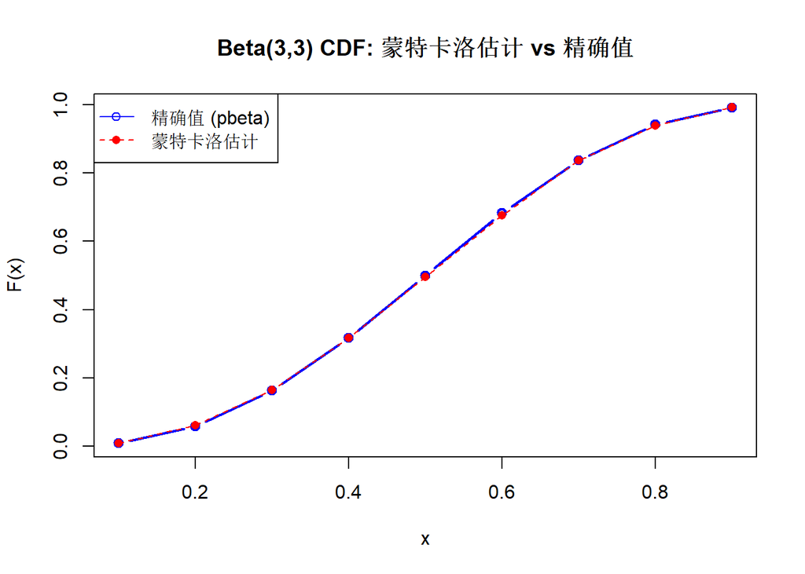

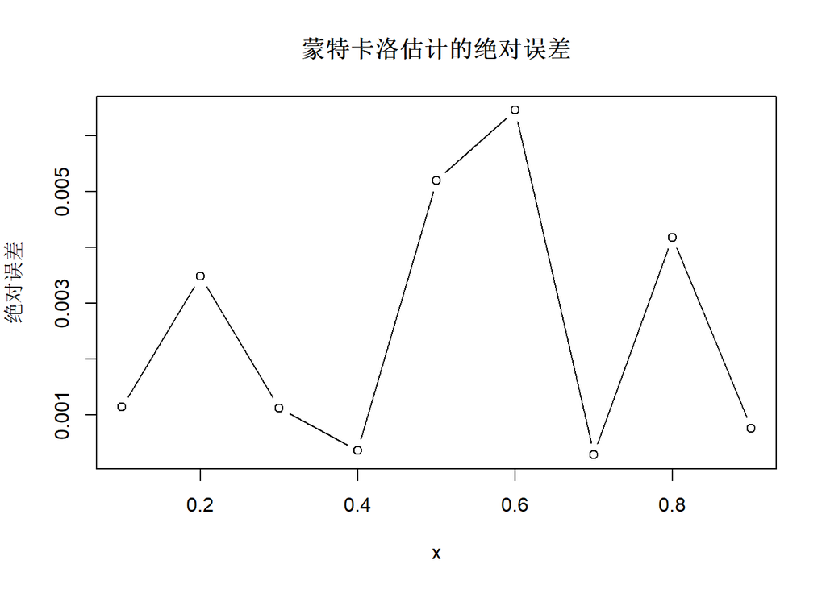

```
##
## 误差统计摘要:
```

```
## 平均绝对误差: 0.002553333
```

```
## 最大绝对误差: 0.00646
```

```
## 平均相对误差: 0.02518498
```

蒙特卡洛方法在估计 Beta分布 CDF 方面的性能较好

### 6.6

#### 6.6.1 计算协方差并进行分析

```
## Cov(e^U, e^(1-U)) = -0.2342106
```

```
## Var(e^U + e^(1-U)) = 0.01564999
```

```
## 简单蒙特卡洛方法的方差 (Var(e^U)) = 0.2420356
```

```
## 使用对立变量法的估计量方差 = 0.007824994
```

```
## 方差减少百分比 = 96.76701 %
```

### 6.13

#### 6.13.1 初始设置

```
## 真实积分值: 0.400626
```

#### 6.13.2 方法1：使用截断指数分布作为重要性函数

#### 6.13.3 方法2：使用截断正态分布作为重要性函数

#### 6.13.4 比较两种方法并设置数据、比较结果

```
##
## 方法1 (截断指数分布):
```

```
## 估计值: 0.4009085
```

```
## 方差: 3.184215e-06
```

```
## 相对误差: 0.0007050843
```

```
##
## 方法2 (截断正态分布):
```

```
## 估计值: 0.4009636
```

```
## 方差: 1.174869e-07
```

```
## 相对误差: 0.00084279
```

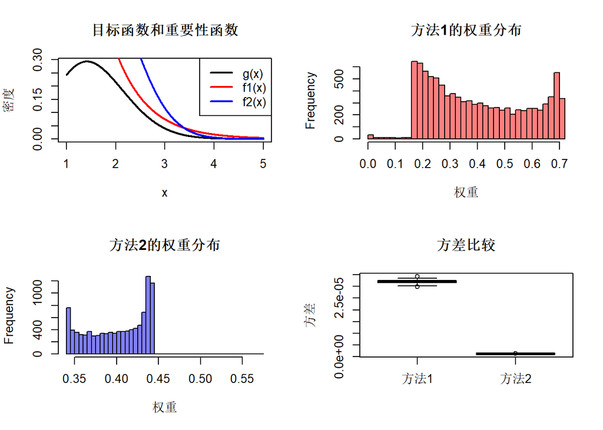

```
##
## 方差比较 (基于 100 次重复实验):
```

```
## 方法1平均方差: 3.204674e-05
```

```
## 方法2平均方差: 1.179908e-06
```

```
## 方差比 (方法1/方法2): 27.16037
```

```
##
## 结论分析:
```

```
## 方法2 (截断正态分布) 产生更小的方差，因为其形状更接近目标函数 g(x)。
## 截断正态分布能更好地匹配目标函数的形状，特别是在尾部行为上。
```

```
##
## 效率分析:
```

```
## 效率比 (方法2/方法1): 0.03681835
```

```
## 方法2比方法1效率高 27.16 倍
```

### Monte Carlo experiment

```
## n = 10000: 平均计算时间 = 1.2300 秒
## n = 20000: 平均计算时间 = 2.3600 秒
## n = 40000: 平均计算时间 = 3.6800 秒
## n = 60000: 平均计算时间 = 4.4400 秒
## n = 80000: 平均计算时间 = 6.1400 秒
```

```
##
## 回归分析结果:
```

```
##
## Call:
## lm(formula = a_n ~ t_n, data = data)
##
## Residuals:
##        1        2        3        4        5
## -0.29375  0.23952  0.28797 -0.28250  0.04876
##
## Coefficients:
##              Estimate Std. Error t value Pr(>|t|)
## (Intercept) 1.005e+00  2.626e-01   3.828  0.03140 *
## t_n         5.631e-06  4.828e-07  11.665  0.00135 **
## ---
## Signif. codes:  0 '***' 0.001 '**' 0.01 '*' 0.05 '.' 0.1 ' ' 1
##
## Residual standard error: 0.3208 on 3 degrees of freedom
## Multiple R-squared:  0.9784, Adjusted R-squared:  0.9712
## F-statistic: 136.1 on 1 and 3 DF,  p-value: 0.001353
```

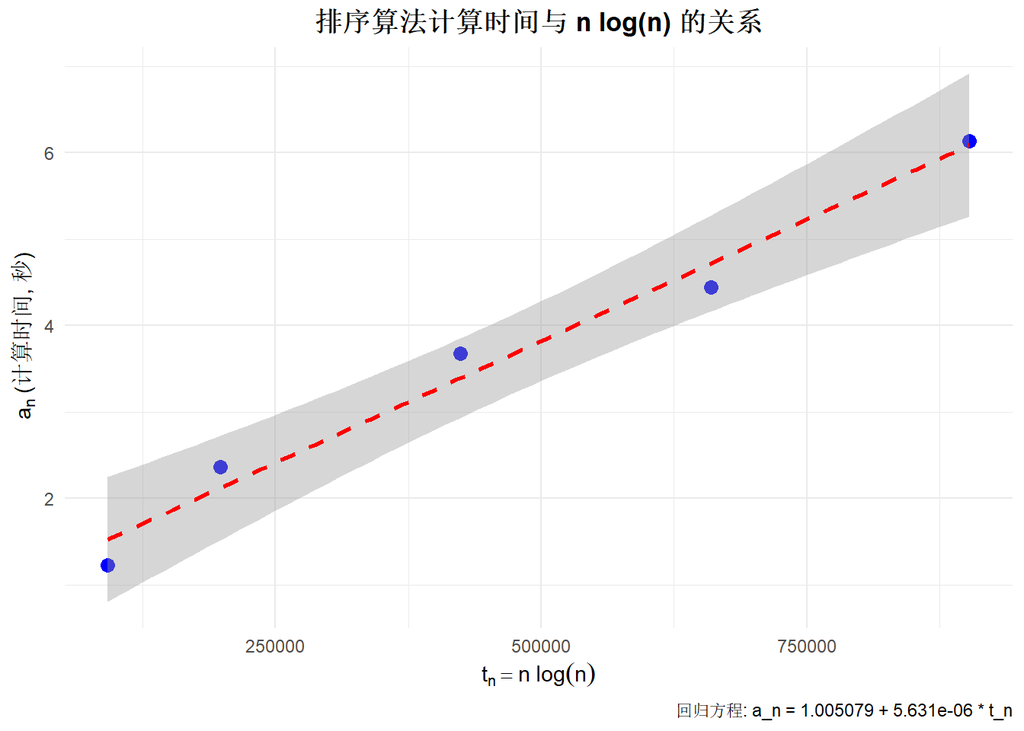

```
##
## 详细数据:
```

```
##        t_n  a_n
## 1  92103.4 1.23
## 2 198069.8 2.36
## 3 423865.4 3.68
## 4 660126.0 4.44
## 5 903182.6 6.14
```